# Aulaa 10 e 11 - Regressão Logística, construção do modelo

13/10/2022

Para a base de dados [Titanic](https://www.kaggle.com/datasets/brendan45774/test-file), escolha os preditores do modelo de regressão logística capaz de explicar a probabilidade de um passageiro ter sobrevivido ao acidente ocorrido com a embarcação.

Utilize a Estatística do Desvio, o Critério de Informação de Akaike e o Critério de Informação Baiesiano para auxiliar na decisão de incluir ou não variáveis ao modelo.

Vamos começar abrindo os dados e vendo o formato do arquivo:

Observação: A página que o exercício aponta é para uma base de testes, e nessa base a sobrevivência ou não é 100% definida pelo gênero do passageiro (100% das mulheres sobrevivem e 100% dos homens não). Entretanto, encontrei a base de treino equivalente e vou usá-la aqui nesse exercício.

```r
df = read.csv('train.csv')
head(df)
```

```
##   PassengerId Survived Pclass
## 1           1        0      3
## 2           2        1      1
## 3           3        1      3
## 4           4        1      1
## 5           5        0      3
## 6           6        0      3
##                                                  Name    Sex Age SibSp Parch
## 1                             Braund, Mr. Owen Harris   male  22     1     0
## 2 Cumings, Mrs. John Bradley (Florence Briggs Thayer) female  38     1     0
## 3                              Heikkinen, Miss. Laina female  26     0     0
## 4        Futrelle, Mrs. Jacques Heath (Lily May Peel) female  35     1     0
## 5                            Allen, Mr. William Henry   male  35     0     0
## 6                                    Moran, Mr. James   male  NA     0     0
##             Ticket    Fare Cabin Embarked
## 1        A/5 21171  7.2500              S
## 2         PC 17599 71.2833   C85        C
## 3 STON/O2. 3101282  7.9250              S
## 4           113803 53.1000  C123        S
## 5           373450  8.0500              S
## 6           330877  8.4583              Q
```

```r
summary(df)
```

```
##   PassengerId       Survived          Pclass          Name
##  Min.   :  1.0   Min.   :0.0000   Min.   :1.000   Length:891
##  1st Qu.:223.5   1st Qu.:0.0000   1st Qu.:2.000   Class :character
##  Median :446.0   Median :0.0000   Median :3.000   Mode  :character
##  Mean   :446.0   Mean   :0.3838   Mean   :2.309
##  3rd Qu.:668.5   3rd Qu.:1.0000   3rd Qu.:3.000
##  Max.   :891.0   Max.   :1.0000   Max.   :3.000
##
##      Sex                 Age            SibSp           Parch
##  Length:891         Min.   : 0.42   Min.   :0.000   Min.   :0.0000
##  Class :character   1st Qu.:20.12   1st Qu.:0.000   1st Qu.:0.0000
##  Mode  :character   Median :28.00   Median :0.000   Median :0.0000
##                     Mean   :29.70   Mean   :0.523   Mean   :0.3816
##                     3rd Qu.:38.00   3rd Qu.:1.000   3rd Qu.:0.0000
##                     Max.   :80.00   Max.   :8.000   Max.   :6.0000
##                     NA's   :177
##     Ticket               Fare           Cabin             Embarked
##  Length:891         Min.   :  0.00   Length:891         Length:891
##  Class :character   1st Qu.:  7.91   Class :character   Class :character
##  Mode  :character   Median : 14.45   Mode  :character   Mode  :character
##                     Mean   : 32.20
##                     3rd Qu.: 31.00
##                     Max.   :512.33
##
```

As 12 variáveis significam:

- PassengerId: ID único
- Survived: Se o passageiro sobreviveu ao naufrágio. 1 (SIM) e 0 (NÃO)
- PClass: Classe do passageiro. 1 (primeira classe), 2 (segunda classe), 3 (terceira classe)
- Name: Nome
- Sex: Gênero
- Age: Idade
- Sibsp: (siblings/spouses) número de irmãos e cônjuges embarcados
- Parch: (parents/children) número de pais e filhos embarcados
- Ticket: Número do ticket do passageiro
- Fare: Tarifa paga
- Cabin: Cabine
- Embarked: Portão de embarque (C = Cherbourg; Q = Queenstown; S = Southampton)

Tendo em vista esses dados, vamos considerar apenas os dados que indicam de alguma forma características de passageiros: class, sex, age, sibsp, parch, fare, embarked. Vamos começar selecionando apenas essas variáveis e tratando algumas dessas variáveis como factors:

Observação: Apesar de age ser uma variável importante, há 177 registros sem essa informação (NA). Vamos desconsiderar age para fins desse exercício. Em outra situação eu tenderia a propor dois modelos, um para quando age está disponível e outro caso contrário.

```r
df = df[,c('Survived', 'Pclass', 'Sex', 'SibSp', 'Parch', 'Fare', 'Embarked')]
df$Pclass = as.factor(df$Pclass)
df$Sex = as.factor(df$Sex)
df$Embarked = as.factor(df$Embarked)
```

Vamos inspecionar os dados agora de Survived versus essas classes para verificar algumas possíveis relações:

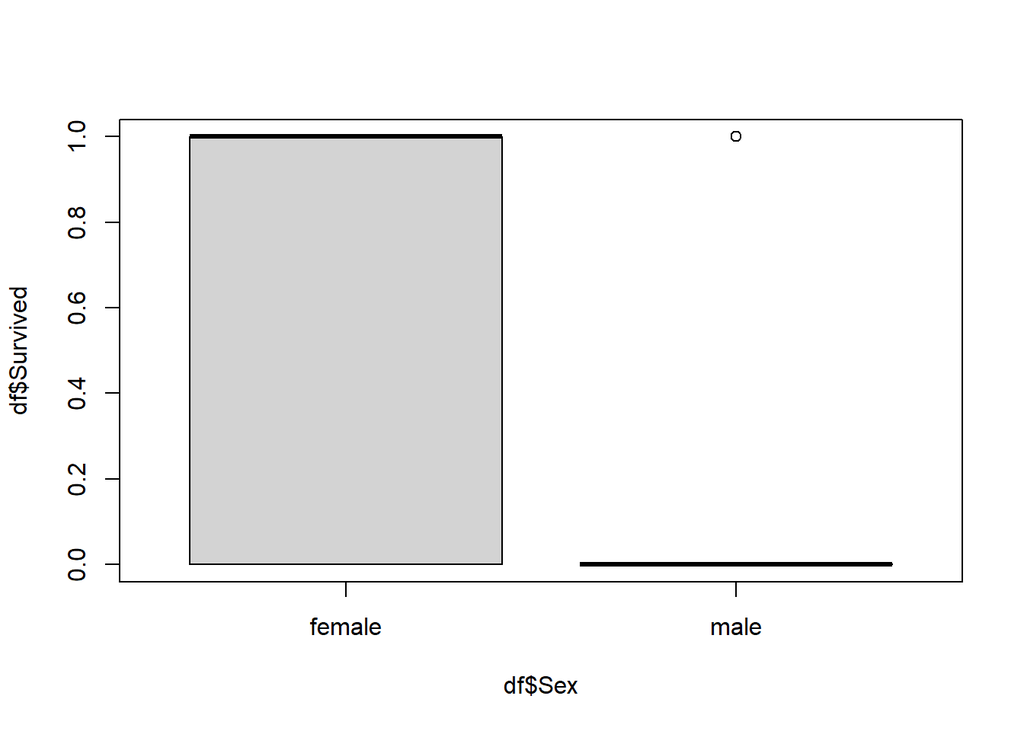

```r
boxplot(df$Survived ~ df$Sex)
```

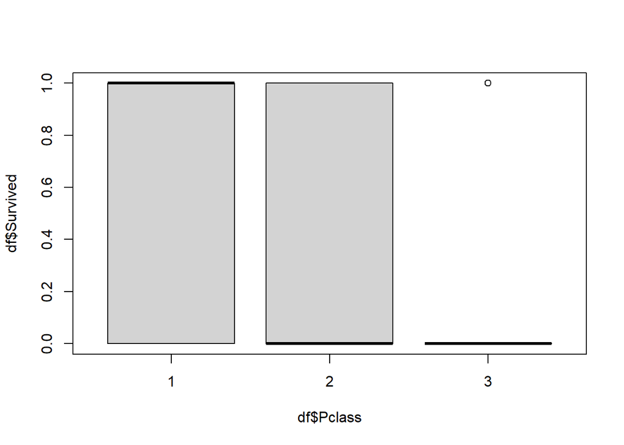

```r
boxplot(df$Survived ~ df$Pclass)
```

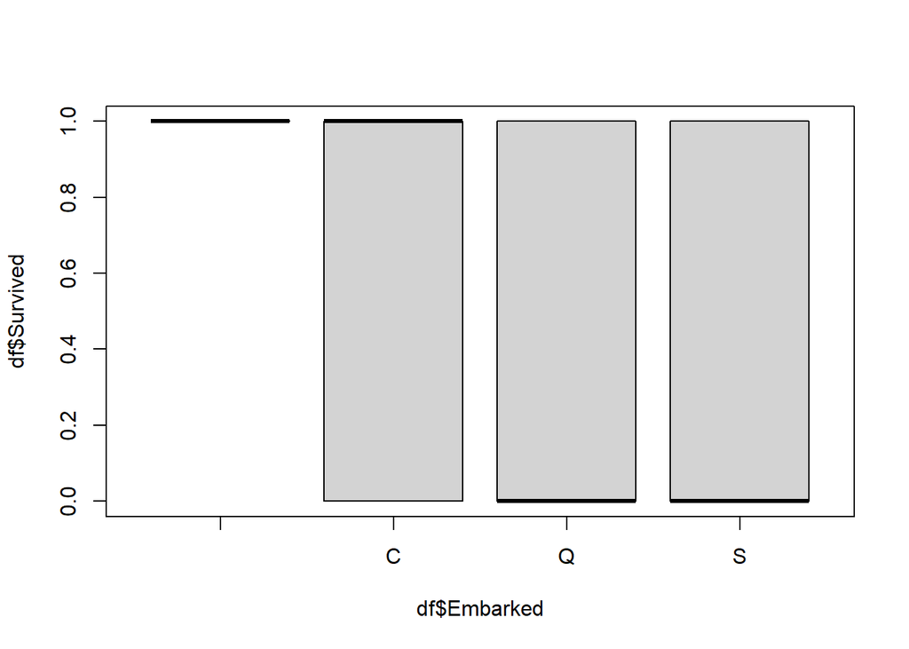

```r
boxplot(df$Survived ~ df$Embarked)
```

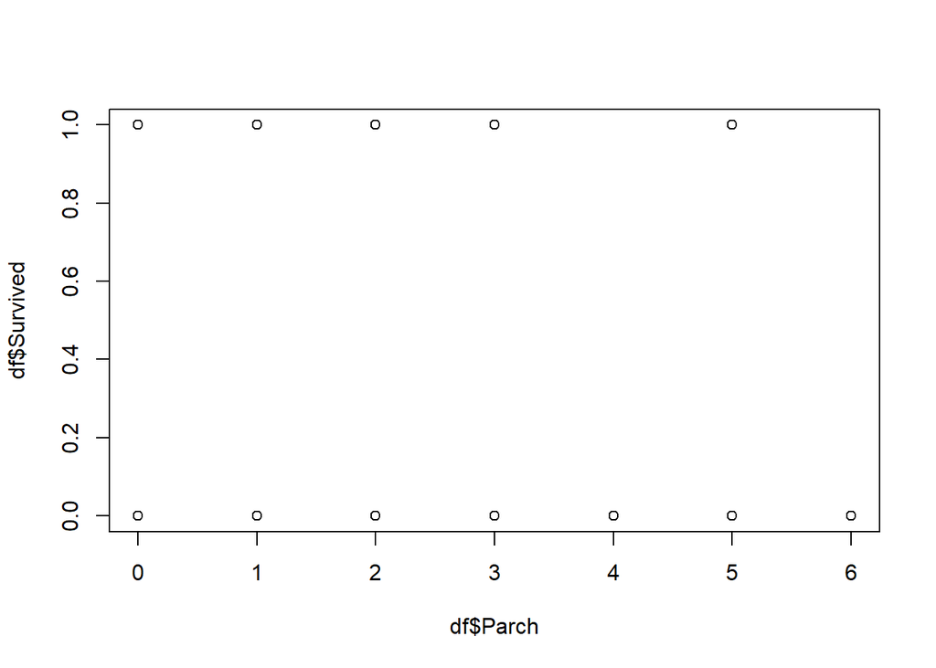

```r
plot(df$Parch, df$Survived)
```

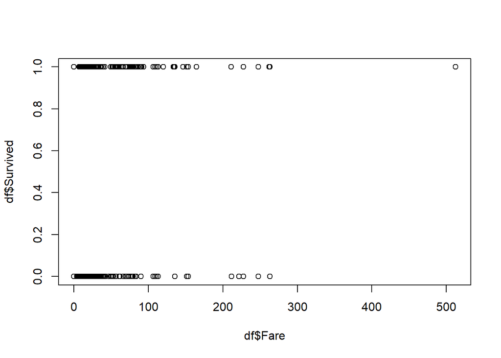

```r
plot(df$Fare, df$Survived)
```

Há uma relação aqui que existe dependência com as variáveis Sex e Pclass. Parece haver também com alguns extratos da variável Embarked.

Mas vamos começar com um modelo com todas as variáveis e descartar aquelas cujos coeficientes são estatisticamente iguais a 0:

```r
modelo = glm( Survived ~ ., family = binomial, data=df)
summary(modelo)
```

```
##
## Call:
## glm(formula = Survived ~ ., family = binomial, data = df)
##
## Deviance Residuals:
##     Min       1Q   Median       3Q      Max
## -2.3283  -0.7239  -0.4477   0.6232   2.5661
##
## Coefficients:
##               Estimate Std. Error z value Pr(>|z|)
## (Intercept)  14.320071 624.193858   0.023   0.9817
## Pclass2      -0.535366   0.282519  -1.895   0.0581 .
## Pclass3      -1.603425   0.270920  -5.918 3.25e-09 ***
## Sexmale      -2.713643   0.198644 -13.661  < 2e-16 ***
## SibSp        -0.230956   0.101489  -2.276   0.0229 *
## Parch        -0.076884   0.114612  -0.671   0.5023
## Fare          0.003075   0.002489   1.236   0.2166
## EmbarkedC   -11.766763 624.193892  -0.019   0.9850
## EmbarkedQ   -11.959792 624.193944  -0.019   0.9847
## EmbarkedS   -12.276601 624.193882  -0.020   0.9843
## ---
## Signif. codes:  0 '***' 0.001 '**' 0.01 '*' 0.05 '.' 0.1 ' ' 1
##
## (Dispersion parameter for binomial family taken to be 1)
##
##     Null deviance: 1186.66  on 890  degrees of freedom
## Residual deviance:  810.58  on 881  degrees of freedom
## AIC: 830.58
##
## Number of Fisher Scoring iterations: 13
```

Removendo:

```r
modelo = glm( Survived ~ Pclass + Sex + SibSp, family = binomial, data=df)
summary(modelo)
```

```
##
## Call:
## glm(formula = Survived ~ Pclass + Sex + SibSp, family = binomial,
##     data = df)
##
## Deviance Residuals:
##     Min       1Q   Median       3Q      Max
## -2.2572  -0.6733  -0.4713   0.6013   2.5182
##
## Coefficients:
##             Estimate Std. Error z value Pr(>|z|)
## (Intercept)  2.46590    0.23121  10.665  < 2e-16 ***
## Pclass2     -0.84708    0.24640  -3.438 0.000586 ***
## Pclass3     -1.86648    0.21487  -8.686  < 2e-16 ***
## Sexmale     -2.74124    0.19048 -14.391  < 2e-16 ***
## SibSp       -0.24651    0.09468  -2.604 0.009224 **
## ---
## Signif. codes:  0 '***' 0.001 '**' 0.01 '*' 0.05 '.' 0.1 ' ' 1
##
## (Dispersion parameter for binomial family taken to be 1)
##
##     Null deviance: 1186.66  on 890  degrees of freedom
## Residual deviance:  819.15  on 886  degrees of freedom
## AIC: 829.15
##
## Number of Fisher Scoring iterations: 4
```

Vamos checar se o modelo proposto é igual ao modelo saturado. Podemos fazer isso checando se o comando abaixo é maior que 0.05 (modelos iguais com signficância de 5%):

```r
1-pchisq(modelo$deviance, modelo$df.residual)
```

```
## [1] 0.946734
```

Dado esse modelo, vamos simplificá-lo removendo, primeiramente, a variável SibSp e, depois removendo também Pclass:

```r
modelo2 = glm( Survived ~ Pclass + Sex, family = binomial, data=df)
summary(modelo2)
```

```
##
## Call:
## glm(formula = Survived ~ Pclass + Sex, family = binomial, data = df)
##
## Deviance Residuals:
##     Min       1Q   Median       3Q      Max
## -2.1877  -0.7312  -0.4476   0.6465   2.1681
##
## Coefficients:
##             Estimate Std. Error z value Pr(>|z|)
## (Intercept)   2.2971     0.2190  10.490  < 2e-16 ***
## Pclass2      -0.8380     0.2447  -3.424 0.000618 ***
## Pclass3      -1.9055     0.2141  -8.898  < 2e-16 ***
## Sexmale      -2.6419     0.1841 -14.351  < 2e-16 ***
## ---
## Signif. codes:  0 '***' 0.001 '**' 0.01 '*' 0.05 '.' 0.1 ' ' 1
##
## (Dispersion parameter for binomial family taken to be 1)
##
##     Null deviance: 1186.66  on 890  degrees of freedom
## Residual deviance:  826.89  on 887  degrees of freedom
## AIC: 834.89
##
## Number of Fisher Scoring iterations: 4
```

```r
modelo3 = glm( Survived ~ Sex, family = binomial, data=df)
summary(modelo3)
```

```
##
## Call:
## glm(formula = Survived ~ Sex, family = binomial, data = df)
##
## Deviance Residuals:
##     Min       1Q   Median       3Q      Max
## -1.6462  -0.6471  -0.6471   0.7725   1.8256
##
## Coefficients:
##             Estimate Std. Error z value Pr(>|z|)
## (Intercept)   1.0566     0.1290   8.191 2.58e-16 ***
## Sexmale      -2.5137     0.1672 -15.036  < 2e-16 ***
## ---
## Signif. codes:  0 '***' 0.001 '**' 0.01 '*' 0.05 '.' 0.1 ' ' 1
##
## (Dispersion parameter for binomial family taken to be 1)
##
##     Null deviance: 1186.7  on 890  degrees of freedom
## Residual deviance:  917.8  on 889  degrees of freedom
## AIC: 921.8
##
## Number of Fisher Scoring iterations: 4
```

Note que a remoção de Pclass e SibSp aumentou o valor do AIC. Caso essas variáveis não tivessem acrescentado utilidade significativa ao modelo, o AIC teria provavelmente diminuído com sua remoção. O aumento do AIC significa que houve aumento considerável da soma dos erros quadráticos com a remoção dessas variáveis.

Assim, como resolução para o exercício, o modelo foi definido assim:

```r
modelo = glm( Survived ~ Pclass + Sex + SibSp, family = binomial, data=df)
summary(modelo)
```

```
##
## Call:
## glm(formula = Survived ~ Pclass + Sex + SibSp, family = binomial,
##     data = df)
##
## Deviance Residuals:
##     Min       1Q   Median       3Q      Max
## -2.2572  -0.6733  -0.4713   0.6013   2.5182
##
## Coefficients:
##             Estimate Std. Error z value Pr(>|z|)
## (Intercept)  2.46590    0.23121  10.665  < 2e-16 ***
## Pclass2     -0.84708    0.24640  -3.438 0.000586 ***
## Pclass3     -1.86648    0.21487  -8.686  < 2e-16 ***
## Sexmale     -2.74124    0.19048 -14.391  < 2e-16 ***
## SibSp       -0.24651    0.09468  -2.604 0.009224 **
## ---
## Signif. codes:  0 '***' 0.001 '**' 0.01 '*' 0.05 '.' 0.1 ' ' 1
##
## (Dispersion parameter for binomial family taken to be 1)
##
##     Null deviance: 1186.66  on 890  degrees of freedom
## Residual deviance:  819.15  on 886  degrees of freedom
## AIC: 829.15
##
## Number of Fisher Scoring iterations: 4
```

```r
df2 = read.csv('tested.csv')
df2$Pclass = as.factor(df2$Pclass)
df2$Sex = as.factor(df2$Sex)

predicao = as.integer(predict(modelo3, df2, type = "response") > 0.5)
resposta = df2$Survived
```

Total de dados diferentes:

```r
sum(predicao-resposta)
```

```
## [1] 0
```